# Weaponizing Nationalism on the Global Stage?

## Vitriol in Pro-CCP Tweets Targeting Uyghur Diaspora Regime Critics

## Allison Koh

## Jonathan Nagler

## Joshua A. Tucker

ISA Annual Convention  
March 15, 2023

[figure not shown]

[figure not shown]

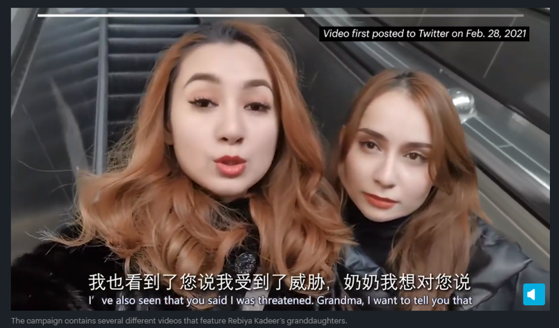

## Motivation

### Diasporas as Regime Threats

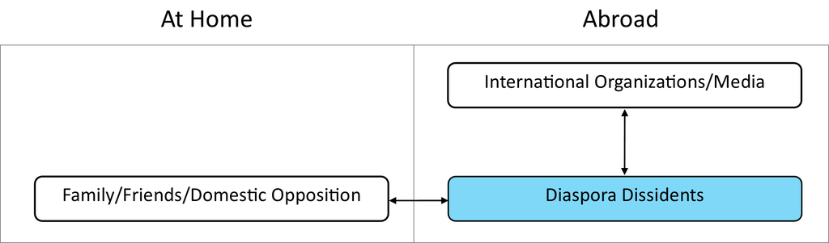

“Horizontal” networks at home 🏡  
(Brinkerhoff 2009; Alonso and Oiarzabal 2010; Bernal 2020)

“Vertical” networks abroad 🌏  
(Keck and Sikkink 1999; Michaelsen 2018; Esberg and Siegel 2020)

➡️ Diaspora dissidents can credibly ruin a state’s international reputation.

## Motivation

### Digital Transnational Repression<sup>1</sup>

- ICTs lower costs, limit attribution, expand the reach of governments beyond their borders.
- Limited regulations on foreign social media enable governments to leverage technical vulnerabilities to silence/discredit regime threats.

### Nationalism and ICTs<sup>2</sup>

- Nationalism involves building a cohesive identity, suppressing minority and diverging voices.
- Communication technologies enable the standardization of nationalist rhetoric and imagery.
- Leveraging national identity may not be perceived as vitriol/hate speech on the global stage.
[^1]: Michaelsen (2020); Al-Jizawi et al. (2020); Dalmasso et al. (2018)
[^2]: Anderson (2006)

## How do pro-government actors evade accountability for attacking diaspora regime critics on foreign social media?

They can leverage facets of national identity to evade consequences for their targeted vitriol.

## Theoretical Expectations

Attacking women and gender minorities is considered to be “more acceptable”<sup>1</sup>.

- Feminists have a relatively high capacity to mobilize support.
- Strongman politics ➡️ gendered curtailments of the public sphere are taken less seriously.

🔎 **Hypothesis 1:** Women* are more likely to be targeted with toxic tweets compared to men.

Strategic use of language can reinforce national identity and protect a state’s global reputation<sup>2</sup>.

- Language education policies have suppressed language minorities in a variety of contexts.
- Vitriol in globally accessible languages might be more heavily scrutinized.

🔎 **Hypothesis 2:** Tweets in English are less likely to be toxic compared to tweets in Chinese.

[^3]: Taylor (1997); Mayer (2012); Enloe (2014); Fincher (2021)
[^4]: Johnson (2012); Wood, Goldsmith, and Horiuchi (2014); Hartig (2020)

## Context: Chinese Repression of Uyghur/Turkic Muslims

[figure not shown]

- Since 2017, the Chinese government has imprisoned more than one million Uyghurs and Turkic-speaking ethnic minorities  
  (Maizland 2022)
- Approximately 11 million Uyghurs are subject to surveillance and state-sponsored information controls
- 7,106 confirmed cases of transnational repression targeting exile and diaspora regime critics in 44 countries since 1997  
  (Lemon, Jardine, and Hall 2022)

Source: AFP via Getty Images

## Data on Prominent Diaspora Regime Critics

**Chinese Transnational Repression of Uyghurs (CTRU)**<sup>1</sup>

- Incidents conducted by the PRC, targeting citizens from the Uyghur Region since 1997
- Cases identified from existing reports, newswires, global datasets; verified by diaspora groups
- Degree of repression measured on a 3-point ordinal scale

**Sampling criteria**

- 2+ incidents of stage 1 repression; being *put on notice* (threats, arrest warrants, etc.)
- Has a Twitter account

[^5]: Lemon, Jardine, and Hall (2022); Dukalskis et al. (2022)

## Twitter Data

[figure not shown]

## Empirical Strategy

### Identifying Pro-government Tweets

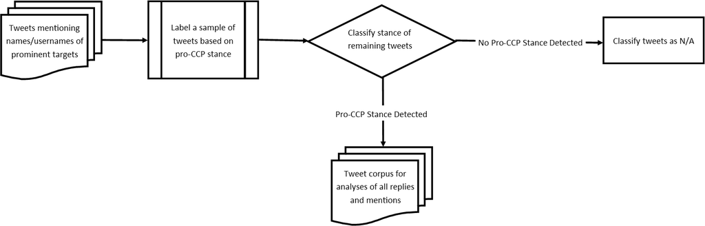

## Empirical Strategy

### Identifying Pro-government Tweets

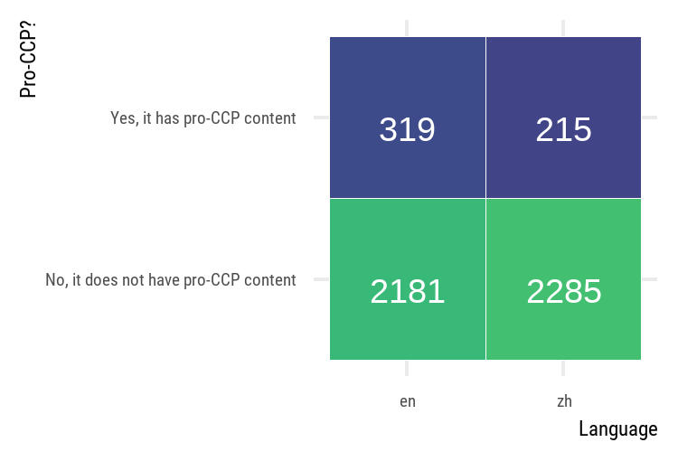

## Empirical Strategy

### Measuring Toxicity

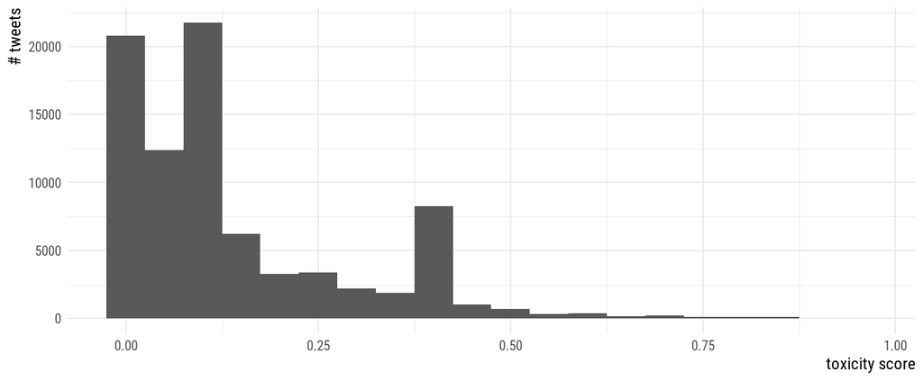

- Does a rude, disrespectful, or unreasonable comment make the target leave a discussion?
- Estimated with the API
- Adjustments to be made for measurement biases based on pronouns used and language

## Preliminary Analysis

Based on t-tests using the manually labeled pro-CCP tweets…

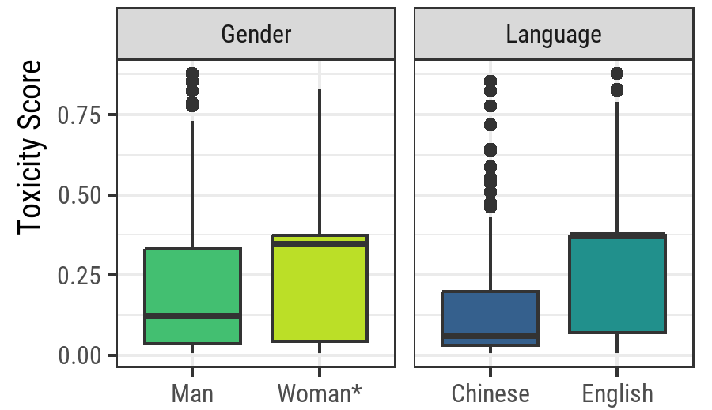

- **H1**: Women more likely to be targeted with toxicity ✅
- **H2**: Chinese tweets more likely to be toxic ❎

## Conclusion

- States that engage in domestic human rights abuses have a vested interest in suppressing diaspora dissent on foreign social media.
- Pro-government actors—while varied in their affiliations and motives—can weaponize national identity to play into global norms; evade platforms’ community guidelines
- Preliminary hypotheses demonstrate that women are more likely to be targeted with vitriol, while differences in the use of language are unclear.
- This paper offers an empirical basis for taking a target-centered approach to studying the “grey areas” of digital transnational repression on foreign platforms.

### Next steps

- Improve BERT-based models to scale up tweet labels and analyses
- Adjusting for gender/language measurement biases

# Thank you!

koh@hertie-school.org

https://allisonkoh.github.io/

@allisonwkoh@mastodon.social🎓

@allisonwkoh@fosstodon.org📊

@allisonkoh_

## References

Al-Jizawi, Noura, S. Antis, S. Chan, A. Senft, and R. J. Deibert. 2020. “Digital Transnational Repression.” The Citizen Lab. https://citizenlab. ca/2020/11/annotated ….

Alonso, Andoni, and Pedro Oiarzabal. 2010. *Diasporas in the New Media Age: Identity, Politics, and Community*. University of Nevada Press.

Anderson, Benedict R. O’G. 2006. *Imagined Communities: Reflections on the Origin and Spread of Nationalism*. Rev. ed. London ; New York: Verso.

Bernal, Victoria. 2020. “African Digital Diasporas: Technologies, Tactics, and Trends: Introduction.” *African Diaspora* 12 (1-2): 1–10.

Brinkerhoff, Jennifer M. 2009. *Digital Diasporas: Identity and Transnational Engagement*. Cambridge University Press.

Dalmasso, Emanuela, Adele Del Sordi, Marlies Glasius, Nicole Hirt, Marcus Michaelsen, Abdulkader S. Mohammad, and Dana Moss. 2018. “Intervention: Extraterritorial Authoritarian Power.” *Political Geography* 64 (May): 95–104. https://doi.org/10.1016/j.polgeo.2017.07.003.

Dukalskis, Alexander, Saipira Furstenberg, Yana Gorokhovskaia, John Heathershaw, Edward Lemon, and Nate Schenkkan. 2022. “Transnational Repression: Data Advances, Comparisons, and Challenges.” *Political Research Exchange* 4 (1): 2104651. https://doi.org/10.1080/2474736X.2022.2104651.

Enloe, Cynthia. 2014. *Bananas, Beaches and Bases: Making Feminist Sense of International Politics*. Univ of California Press.

Esberg, Jane, and Alexandra Siegel. 2020. “How Exile Shapes Online Opposition: Evidence from Venezuela.”

Fincher, Leta Hong. 2021. *Betraying Big Brother: The Feminist Awakening in China*. Paperback edition. London New York (N.Y.): Verso.

Hartig, Falk. 2020. “Rethinking China’s Global ‘Propaganda’blitz.” *Global Media and Communication* 16 (1): 3–18.

Johnson, Eric J. 2012. “Arbitrating Repression: Language Policy and Education in Arizona.” *Language and Education* 26 (1): 53–76. https://doi.org/10.1080/09500782.2011.615936.

Keck, Margaret E., and Kathryn Sikkink. 1999. “Transnational Advocacy Networks in International and Regional Politics.” *International Social Science Journal* 51 (159): 89–101. https://doi.org/10.1111/1468-2451.00179.

Lemon, Edward, Bradley Jardine, and Natalie Hall. 2022. “Globalizing Minority Persecution: China’s Transnational Repression of the Uyghurs.” *Globalizations*, 1–17.

Maizland, Lindsay. 2022. “China’s Repression of Uyghurs in Xinjiang.” *Council on Foreign Relations*. https://www.cfr.org/backgrounder/china-xinjiang-uyghurs-muslims-repression-genocide-human-rights.

Mayer, Tamar. 2012. “Gender Ironies of Nationalism: Setting the Stage.” In *Gender Ironies of Nationalism*, 1–22. Routledge.

Michaelsen, Marcus. 2018. “Exit and Voice in a Digital Age: Iran’s Exiled Activists and the Authoritarian State.” *Globalizations* 15 (2): 248–64.

———. 2020. “The Silencing Effect of Digital Transnational Repression.” *Hivos*. https://hivos.org/the-silencing-effect-of-digital-transnational-repression/.

Taylor, Diana. 1997. *Disappearing Acts: Spectacles of Gender and Nationalism in Argentina’s" Dirty War"*. Duke University Press.

Wood, Terence, Benjamin E. Goldsmith, and Yusaku Horiuchi. 2014. “Doing Well by Doing Good: The Impact of Foreign Aid on Foreign Public Opinion.”